# QTM 151 - Assignment 10

## Try to submit as an HTML file

Print your name below

```python
# Write your answer here

print("Shannon Zhang")
```

Import the libraries "matplotlib.pyplot" and "pandas"

```python
# Write your answer here

import matplotlib.pyplot as plt
import pandas as pd
```

In this assigment you will work with data on exchange rates,  
for two currencies:

- 1 dollar (USD) to chinese yuan (RMB)
- 1 dollar (USD) to japanese yen (JPY).

For this lecture, you will need the material from  
Lecture 20 and 22.

(a) Import and parse dates

- Import the dataset "exchangerates.csv"
- Parse the "date_string" column with `pd.to_datetime()`
- To get full points, set the "format" option using wildcards as in Lecture 21.

```python
# Write your own code

exchange = pd.read_csv("data_raw/exchangerates.csv")
exchange["date_string"] = pd.to_datetime(exchange["date_string"], format = "%Y, %A, %b %d")
#exchange["date_string"]  = exchange["date_string"].dt.strftime("%m")
```

(b) Plot multiple time series

- Create a line plot plot which has the "usd_to_rmb" and "usd_to_jpy" on the y-axis  
  and the date on the x-axis
- Label the x-axis, the y-axis, and the title
- Add a legend and set the names to "1 USD to RMB" and "1 USD to JPY"

Hint: See Lecture 22 for how to plot multiple columns  
Hint: Remember to include the legend names as a list `[...]`

```
<function matplotlib.pyplot.show(close=None, block=None)>
```

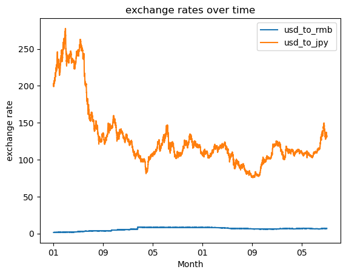

```python
# Write your own code


exchange[["date_string","usd_to_rmb","usd_to_jpy"]].set_index("date_string").plot()
plt.xlabel("Month")
plt.ylabel("exchange rate")
plt.title("exchange rates over time")
plt.show
```

(c) Flag subset of data and plot

- Create a boolean vector (True/False) "bool_cond" which checks whether  
  "usd_to_jpy" is below 100
- Generate a line plot with the "usd_to_jpy" series, label the axes and the title
- Use the command `plt.fill_between()` as in Lecture 22 to create a shaded region  
  for time periods where "bool_cond" is true.

[output not shown]

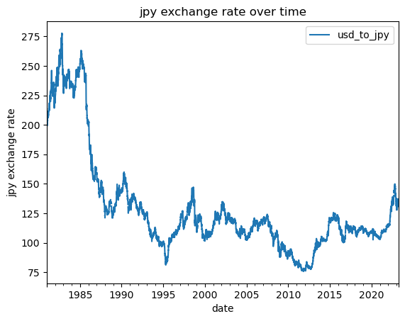

```python
# Write your own code
exchange["month"] = exchange["date_string"].dt.strftime("%m")

exchange["bool_cond"] = exchange["usd_to_jpy"] < 100
exchange[["date_string","usd_to_jpy"]].set_index("date_string").plot()
plt.xlabel("date")
plt.ylabel("jpy exchange rate")
plt.title("jpy exchange rate over time")

vec_y = exchange["usd_to_jpy"]
plt.fill_between(x = exchange["month"],
                 y1 = vec_y.min(),
                 y2 = vec_y.max(),
                 where = exchange["bool_cond"],
                 alpha = 0.2,color = "red")
plt.show()
```

(d) Aggregate dataset by time period

- Create an object "month_config" that uses `pd.Grouper()`, setting the key to  
  the date column and freq to "m" (month)
- Follow the instructions in Lecture 21 to compute an aggregate dataset  
  by month which computes the standard deviation of "usd_to_rmb"
- Display the dataset

```python
# Write your own code

month_config = pd.Grouper(key='date_string', freq='m')
monthdata = (exchange
               .groupby(month_config)
               .agg(exchange_std= ("usd_to_rmb","std"))
               .reset_index())

monthdata
```

|  | date_string | exchange_std |
| --- | --- | --- |
| 0 | 1981-01-31 | 0.019149 |
| 1 | 1981-02-28 | 0.015432 |
| 2 | 1981-03-31 | 0.012636 |
| 3 | 1981-04-30 | 0.017154 |
| 4 | 1981-05-31 | 0.017583 |
| ... | ... | ... |
| 502 | 2022-11-30 | 0.077405 |
| 503 | 2022-12-31 | 0.028203 |
| 504 | 2023-01-31 | 0.052152 |
| 505 | 2023-02-28 | 0.067344 |
| 506 | 2023-03-31 | 0.034796 |

507 rows × 2 columns

(e) Convert a dataset to long format

- Convert the currencies dataset to long format using the following inputs

```
var_name   = "type",
value_name = "exchange_rate",
id_vars    = "date",
value_vars = ["usd_to_rmb","usd_to_jpy"]
```

- Display the dataset

Hint: See Lecture 22 for details on `pd.melt()`

```python
# Write your own code

exchange_long = pd.melt(exchange,
                         var_name = "type",
                         value_name = "exchange_rate",
                         id_vars='date_string',
                         value_vars=['usd_to_rmb','usd_to_jpy'])

exchange_long
```

|  | date_string | type | exchange_rate |
| --- | --- | --- | --- |
| 0 | 1981-01-02 | usd_to_rmb | 1.5341 |
| 1 | 1981-01-05 | usd_to_rmb | 1.5418 |
| 2 | 1981-01-06 | usd_to_rmb | 1.5264 |
| 3 | 1981-01-07 | usd_to_rmb | 1.5264 |
| 4 | 1981-01-08 | usd_to_rmb | 1.5264 |
| ... | ... | ... | ... |
| 22037 | 2023-03-27 | usd_to_jpy | 131.4900 |
| 22038 | 2023-03-28 | usd_to_jpy | 130.9700 |
| 22039 | 2023-03-29 | usd_to_jpy | 132.6900 |
| 22040 | 2023-03-30 | usd_to_jpy | 132.7100 |
| 22041 | 2023-03-31 | usd_to_jpy | 132.7500 |

22042 rows × 3 columns